# Assignment V

Lukas Brunner

5 2 2021

GitHub-Repo : https://github.com/lubrunn/DSPM_Assignment

# Exercise 1

### Exercise 1.1

Perform a first GET request, that searches for event venues in Germany (countryCode = “DE”). Extract the content from the response object and inspect the resulting list. Describe what you can see.

```r
resp_ven <- GET(glue("https://app.ticketmaster.com/discovery/v2/venues?apikey={key}&locale=*&countryCode=DE"))
con_ven <- fromJSON(content(resp_ven, as = "text"))
```

The resulting list contains three elements. The first, _embedded, contains the information of interest such as as the name and the location of the venues. The second element is the _links object and contains links to data sets. The last element is the page object. It contains information about the current page in the data source.

### Exercise 1.2

Extract the name, the city, the postalCode and address, as well as the url and the longitude and latitude of the venues to a data frame.

```r
ven_df <- con_ven$`_embedded`$venues

# subset relevant columns
ven_df <- subset(ven_df, select = c(name, city, postalCode, address, url,
                                    location))

# transform to proper data.frame without nested dfs and rename long, lat
ven_df <- do.call(data.frame, ven_df) %>% rename("longitude" = "location.longitude",
                                                 "latitude" = "location.latitude",
                                                 "city" = "name.1",
                                                 "address" = "line1")
# convert long, lat to numeric
ven_df <-  ven_df %>%
  mutate_at(c('longitude', 'latitude'), as.numeric)

glimpse(ven_df)
```

```
## Rows: 20
## Columns: 7
## $ name       <chr> "Gruenspan", "Philharmonie (Großer Saal)", "Beatpol", "M...
## $ city       <chr> "Hamburg", "Berlin", "Dresden", "Ludwigsburg", "Berlin",...
## $ postalCode <chr> "22767", "10785", "01157", "71638", "12435", "79108", "7...
## $ address    <chr> "Grosse Freiheit 58", "Herbert-von-Karajan-Straße 1", "A...
## $ url        <chr> "http://www.ticketmaster.de/venue/287155", "https://www....
## $ longitude  <dbl> 9.958075, 13.368960, 13.674710, 9.182400, 13.420540, 7.8...
## $ latitude   <dbl> 53.55188, 52.51007, 51.06498, 48.89121, 52.49945, 48.015...
```

# Exercise 2

Have a closer look at the list element named page. Did your GET request from exercise 3 return all event locations in Germany? Obviously not - there are of course much more venues in Germany than those contained in this list. Your GET request only yielded the first results page containing the first 20 out of several thousands of venues. \ Check the API documentation under the section Venue Search. How can you request the venues from the remaining results pages? \ Write a for loop that iterates through the results pages and performs a GET request for all venues in Germany. After each iteration, extract the seven variables name, city, postalCode, address, url, longitude, and latitude. Join the information in one large data frame.

```r
tot_pages <- con_ven$page$totalPages - 1
ven_df_all <- ven_df
for (i in 1:tot_pages){
  resp_ven_l <- GET(glue("https://app.ticketmaster.com/discovery/v2/venues?apikey={key}&locale=*&countryCode=DE&page={i}"))
  con_ven_l <- fromJSON(content(resp_ven_l, as = "text"))

  ven_df_l <- con_ven_l$`_embedded`$venues

  # sometimes get spike arrest violation, if this happens skip to next loop
  if (!is.null(ven_df_l)){

  #build in condition that skips loop if response does not contain all needed variables
  vars_want <- c("name", "city", "postalCode",
                 "address", "url", "location")

  # find missing columns
  vars_missing <- setdiff(vars_want, names(ven_df_l))

  # insert missing column with NAs
  for (missing_col in vars_missing){
    if (missing_col == "location"){
      ven_df_l[[missing_col]] <- data.frame("longitude" = replicate(nrow(ven_df_l), NA),
                                          "latitude" = replicate(nrow(ven_df_l),NA))
    } else if (missing_col == "address") {
      ven_df_l[[missing_col]] <- data.frame("line1" = replicate(nrow(ven_df_l), NA))
    } else {ven_df_l[[missing_col]] <- NA}

  }

  #if (sum(vars_want %in% names(ven_df_l)) == 6) {

  #print(glue("Page {i} contained all needed information."))
  # subset relevant columns
  ven_df_l <- subset(ven_df_l, select = c(name, city, postalCode, address, url,
                                      location))
  # unnest dataframe
  ven_df_l <- do.call(data.frame, ven_df_l)

  # condition for the case of adress containing two columns
  # number of columns with address
  num_add <- length(grep(x = colnames(ven_df_l), pattern = "^address"))
  # if there are multiple address columns only keep first
  if (num_add >= 2){
  ven_df_l <- ven_df_l %>% select(-address.line2) %>% rename("line1" = "address.line1")
  }


   # transform to proper data.frame without nested dfs and rename long, lat

  ven_df_l  <- ven_df_l %>% rename("longitude" = "location.longitude",
                                                   "latitude" = "location.latitude",
                                                   "city" = "name.1",
                                                 "address" = "line1")

  # convert long, lat to numeric
  ven_df_l <-  ven_df_l %>%
    mutate_at(c('longitude', 'latitude'), as.numeric)

  # append to entire df
  ven_df_all <- rbind(ven_df_all, ven_df_l)
  }
  #} #else {print(glue("Page {i} skipped because of missing data."))}
  # go to sleep after each loop
  sleep_time <- 0.5
  #print(glue("Going to sleep for {sleep_time} seconds."))
  Sys.sleep(sleep_time)

}




glimpse(ven_df_all)
```

```
## Rows: 12,176
## Columns: 7
## $ name       <chr> "Gruenspan", "Philharmonie (Großer Saal)", "Beatpol", "M...
## $ city       <chr> "Hamburg", "Berlin", "Dresden", "Ludwigsburg", "Berlin",...
## $ postalCode <chr> "22767", "10785", "01157", "71638", "12435", "79108", "7...
## $ address    <chr> "Grosse Freiheit 58", "Herbert-von-Karajan-Straße 1", "A...
## $ url        <chr> "http://www.ticketmaster.de/venue/287155", "https://www....
## $ longitude  <dbl> 9.958075, 13.368960, 13.674710, 9.182400, 13.420540, 7.8...
## $ latitude   <dbl> 53.55188, 52.51007, 51.06498, 48.89121, 52.49945, 48.015...
```

# Exercise 3

Add points to the map indicating the locations of the event venues across Germany.

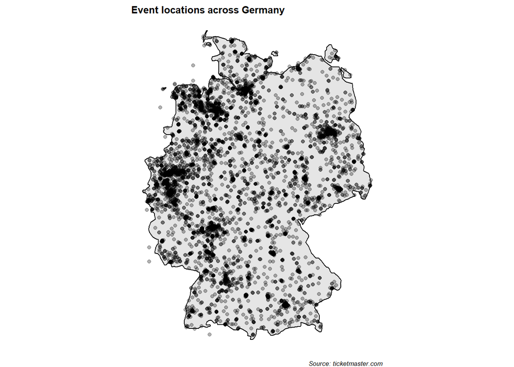

```r
ven_df_all %>% drop_na(c(longitude, latitude)) %>%
  filter(between(longitude, 5.866944, 15.043611),
         between(latitude, 47.271679, 55.0846)) %>%
ggplot() +
geom_polygon(aes(x = long, y = lat, group = group), data = map_data("world", region = "Germany"), fill = "grey90",color = "black") +
theme_void() + coord_quickmap() +
labs(title = "Event locations across Germany", caption = "Source: ticketmaster.com") +
theme(title = element_text(size=8, face='bold'),
plot.caption = element_text(face = "italic")) +
  geom_point(aes(x = longitude, y = latitude),
             alpha = 0.3)
```

# Exercise 4

Repeat all the above exercises for a different european country

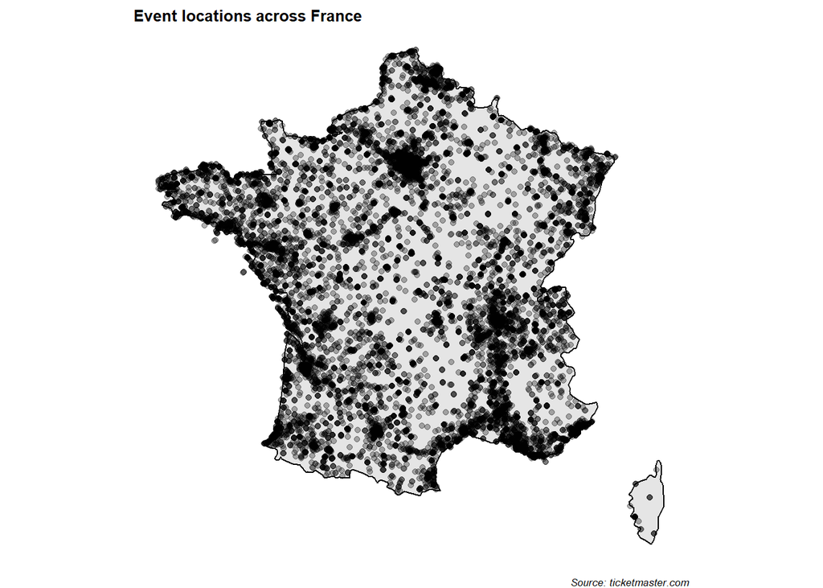

```r
country_code <- "FR"
resp_ven <- GET(glue("https://app.ticketmaster.com/discovery/v2/venues?apikey={key}&locale=*&countryCode={country_code}"))
con_ven <- fromJSON(content(resp_ven, as = "text"))

ven_df <- con_ven$`_embedded`$venues

# subset relevant columns
ven_df <- subset(ven_df, select = c(name, city, postalCode, address, url,
                                    location))

# transform to proper data.frame without nested dfs and rename long, lat
ven_df <- do.call(data.frame, ven_df)

# condition for the case of adress containing two columns
# number of columns with address
num_add <- length(grep(x = colnames(ven_df), pattern = "^address"))
# if there are multiple address columns only keep first
if (num_add >= 2){
ven_df <- ven_df %>% select(-address.line2) %>% rename("line1" = "address.line1")
}

ven_df <- ven_df %>% rename("longitude" = "location.longitude",
                                                 "latitude" = "location.latitude",
                                                 "city" = "name.1",
                                                 "address" = "line1")
# convert long, lat to numeric
ven_df <-  ven_df %>%
  mutate_at(c('longitude', 'latitude'), as.numeric)


#####################################
####### for all pages ###############
#####################################
tot_pages <- con_ven$page$totalPages - 1
ven_df_all <- ven_df
for (i in 1:tot_pages){
  resp_ven_l <- GET(glue("https://app.ticketmaster.com/discovery/v2/venues?apikey={key}&locale=*&countryCode={country_code}&page={i}"))
  con_ven_l <- fromJSON(content(resp_ven_l, as = "text"))

  ven_df_l <- con_ven_l$`_embedded`$venues

  # sometimes get spike arrest violation, if this happens skip to next loop
  if (!is.null(ven_df_l)){

  #build in condition that skips loop if response does not contain all needed variables
  vars_want <- c("name", "city", "postalCode",
                 "address", "url", "location")

  # find missing columns
  vars_missing <- setdiff(vars_want, names(ven_df_l))

  # insert missing column with NAs
  for (missing_col in vars_missing){
    if (missing_col == "location"){
      ven_df_l[[missing_col]] <- data.frame("longitude" = replicate(nrow(ven_df_l), NA),
                                          "latitude" = replicate(nrow(ven_df_l),NA))
    } else if (missing_col == "address") {
      ven_df_l[[missing_col]] <- data.frame("line1" = replicate(nrow(ven_df_l), NA))
    } else {ven_df_l[[missing_col]] <- NA}

  }

  #if (sum(vars_want %in% names(ven_df_l)) == 6) {

  #print(glue("Page {i} contained all needed information."))
  # subset relevant columns
  ven_df_l <- subset(ven_df_l, select = c(name, city, postalCode, address, url,
                                      location))
  # unnest dataframe
  ven_df_l <- do.call(data.frame, ven_df_l)

  # condition for the case of adress containing two columns
  # number of columns with address
  num_add <- length(grep(x = colnames(ven_df_l), pattern = "^address"))
  # if there are multiple address columns only keep first
  if (num_add >= 2){
  ven_df_l <- ven_df_l %>% select(-address.line2) %>% rename("line1" = "address.line1")
  }


   # transform to proper data.frame without nested dfs and rename long, lat

  ven_df_l  <- ven_df_l %>% rename("longitude" = "location.longitude",
                                                   "latitude" = "location.latitude",
                                                   "city" = "name.1",
                                                 "address" = "line1")

  # convert long, lat to numeric
  ven_df_l <-  ven_df_l %>%
    mutate_at(c('longitude', 'latitude'), as.numeric)

  # append to entire df
  ven_df_all <- rbind(ven_df_all, ven_df_l)
  }
  #} #else {print(glue("Page {i} skipped because of missing data."))}
  # go to sleep after each loop
  sleep_time <- 0.5
  #print(glue("Going to sleep for {sleep_time} seconds."))
  Sys.sleep(sleep_time)

}



# plot the locations

ven_df_all %>% drop_na(c(longitude, latitude)) %>%
  filter(between(longitude, -4.8126346, 9.3538177),
         between(latitude, 41.4834416, 51.08361111)) %>%
ggplot() +
geom_polygon(aes(x = long, y = lat, group = group), data = map_data("world", region = "France"), fill = "grey90",color = "black") +
theme_void() + coord_quickmap() +
labs(title = "Event locations across France", caption = "Source: ticketmaster.com") +
theme(title = element_text(size=8, face='bold'),
plot.caption = element_text(face = "italic")) +
  geom_point(aes(x = longitude, y = latitude),
             alpha = 0.3)
```